# Markov Chains with Python

###### By Rohit Pardasani

- A Markov chain is a mathematical system usually defined as a collection of random variables, that transition from one state to another according to certain probabilistic rules.
- These set of transition satisfies the Markov Property, which states that the probability of transitioning to any particular state is dependent solely on the current state and time elapsed, and not on the sequence of state that preceded it.
- This unique characteristic of Markov processes render them memoryless.

When Cj is sad, which isn't very usual: she either goes for a run, goobles down icecream or takes a nap.

From historic data, if she spent sleeping a sad day away. The next day it is 60% likely she will go for a run, 20% she will stay in bed the next day and 20% chance she will pig out on icecream.

When she is sad and goes for a run, there is a 60% chances she'll go for a run the next day, 30% she gorges on icecream and only 10% chances she'll spend sleeping the next day.

Finally, when she indulges on icecream on a sad day, there is a mere 10% chance she continues to have icecream the next day as well, 70% she is likely to go for a run and 20% chance that she spends sleeping the next day.

#### State Diagram

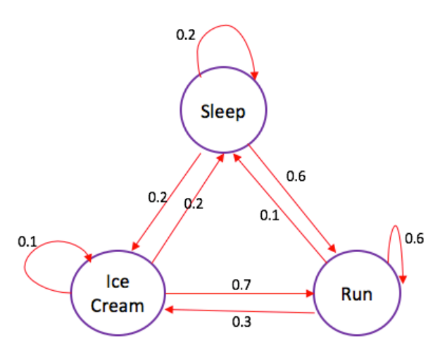

Notice, the arrows exiting a state always sums up to exactly 1, so the entries in each row in the transition matrix must add up to exactly 1.

#### Transition Matrix

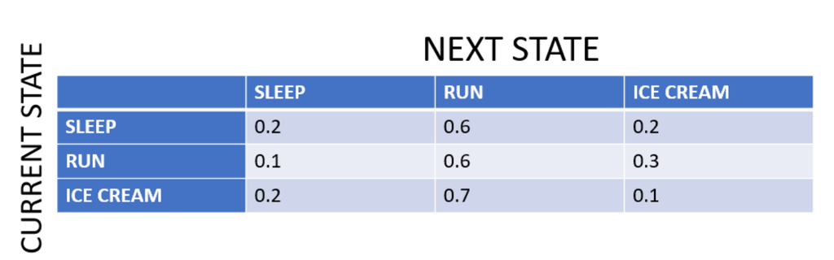

```python
import numpy as np
states = ['Sleep(S)','Run(R)','Ice-Cream(C)']
stateDict = {'Sleep':0,'Run':1,'Ice-Cream':2}
stateDictr = {0:'Sleep',1:'Run',2:'Ice-Cream'}
TM = np.array([[0.2,0.6,0.2],[0.1,0.6,0.3],[0.2,0.7,0.1]])
print('States : ',states)
print(TM)
```

```
States :  ['Sleep(S)', 'Run(R)', 'Ice-Cream(C)']
[[0.2 0.6 0.2]
 [0.1 0.6 0.3]
 [0.2 0.7 0.1]]
```

Starting from the state: sleep (Day-0), what is the probability that Cj will be running (state: run) on Day-2 ?
Theoretically,
$$Pr(X_2=R|X_0=S) = \\ Pr(X_2=R|X_1=S)Pr(X_1=S|X_0=S)+\\ Pr(X_2=R|X_1=R)Pr(X_1=R|X_0=S)+\\ Pr(X_2=R|X_1=C)Pr(X_1=C|X_0=S)$$
$Pr(X_2=R|X_0=S) =(0.6*0.2) + (0.6*0.6) + (0.7*0.2) = 0.12 + 0.36 + 0.14 = 0.62$

```python
import random
from collections import Counter
def nextState(ps,TM):
    r = random.uniform(0,1)
    T1 = TM[stateDict[ps]][0]
    T2 = T1 + TM[stateDict[ps]][1]
    if(r<=T1):
        return stateDictr[0]
    elif(r<=T2):
        return stateDictr[1]
    else:
        return stateDictr[2]

Day2Event = []
for i in range(10000):
    Day2Event.append(nextState(nextState('Sleep',TM),TM))
print('Out of 10000 runs starting from Day:0 Sleep, following is the situation on Day:2\n')
print(Counter(Day2Event))
```

```
Out of 10000 runs starting from Day:0 Sleep, following is the situation on Day:2

Counter({'Run': 6218, 'Ice-Cream': 2448, 'Sleep': 1334})
```

### References

https://www.datacamp.com/community/tutorials/markov-chains-python-tutorial

### Resources

https://setosa.io/ev/markov-chains/